# Rayca Evaluation Task

Jeronimo Parra

28/12/2023

## Single Cell Report

Here we have a example of the single cell analisis of 6 samples from prostate from mouse. I would do the cell ranger execution in a process in nextflow in order to execute in HPC and the upload the h5 data to analice nad visualice in R, calling a Rmarkdown also with nextflow.

I made this analisys at my actual work as a single cell analisys service which we provide to another reserch center. I remove some details about the samples and conclusion in order to not share any sensible data. This analisys was not designed for trayectory analisys but I add some at the end.

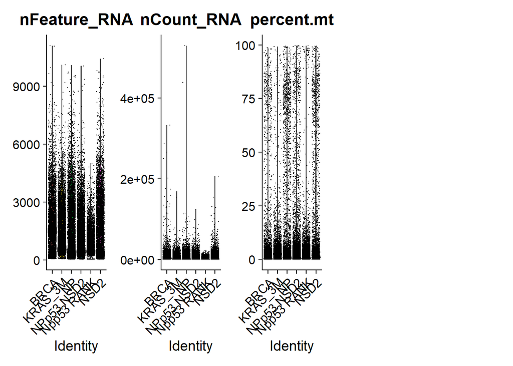

Violin plot of raw data. For every sample we can see the distribution of the values of the variables nFeatures(number of genes by cell), nCount( number of count by cell) and percent.mt which is the mitocondrial RNA percetange found by cell

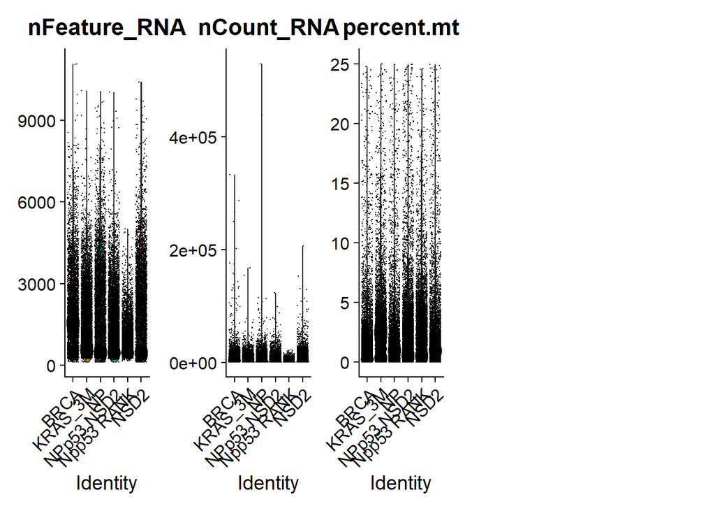

After filtering by number of genes by cell(nFeatures) higher than 100 and by mitocondrial percentage lower than 25

## Find cluster and markers.

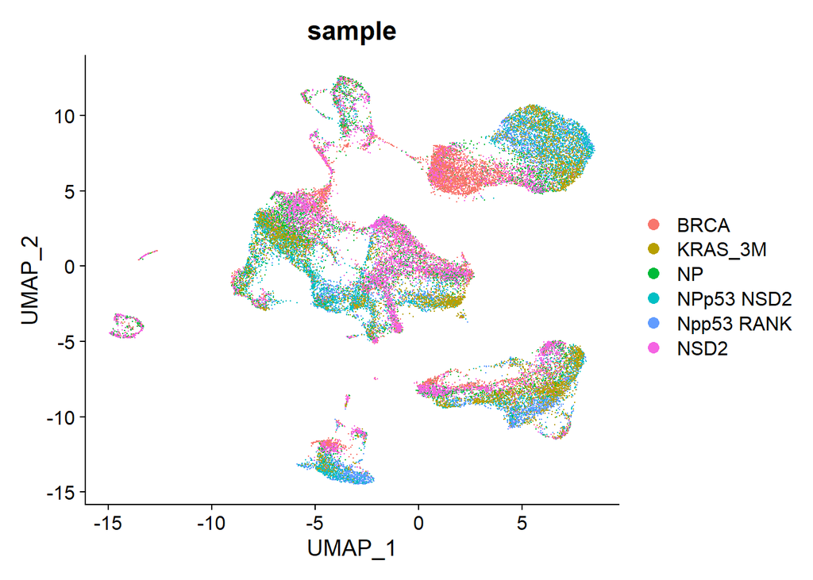

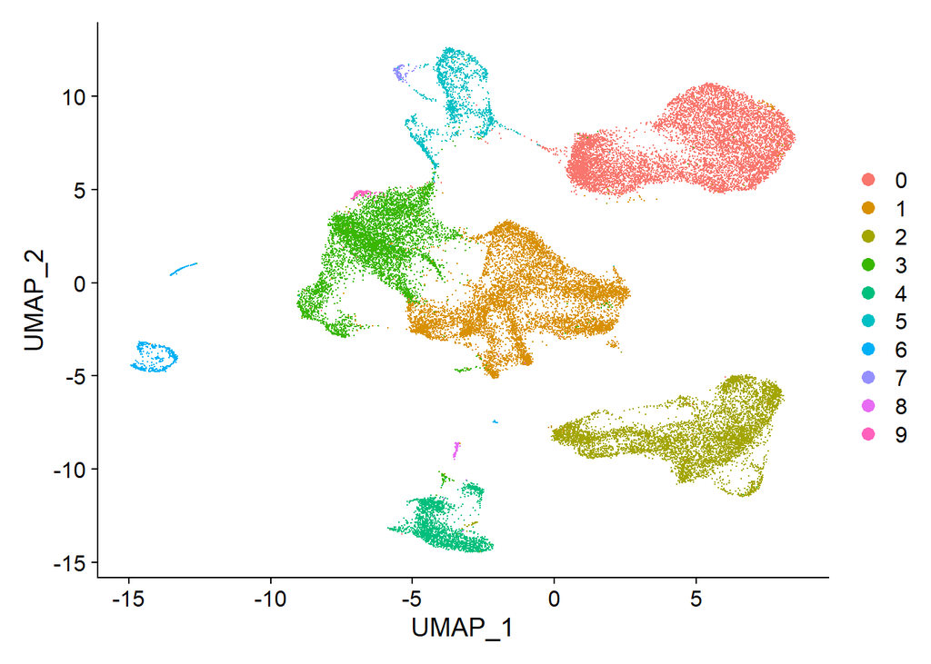

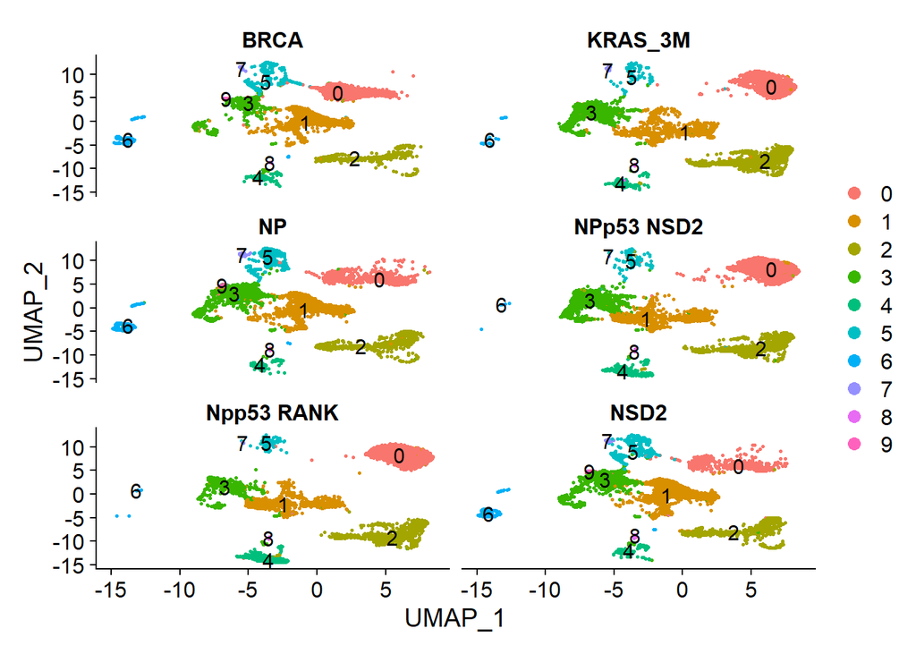

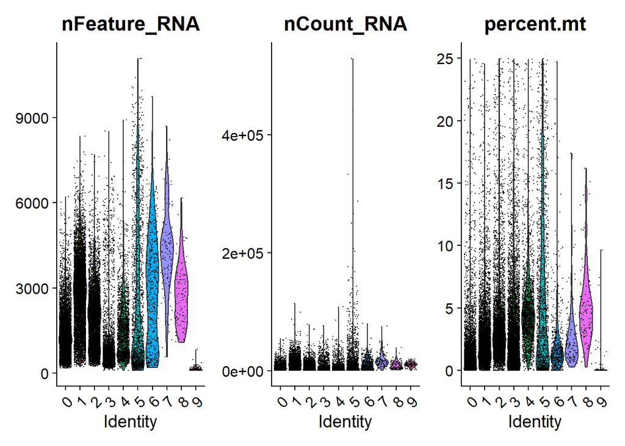